# Lab 4. My first data science project

#### Hint: look on the pandas documentation how to sort values (sort_values() function)

```python
lifeExporder=gapminder['lifeExp']
```

```python
lifeExporder
```

```
0       28.801
1       30.332
2       31.997
3       34.020
4       36.088
         ...
1699    62.351
1700    60.377
1701    46.809
1702    39.989
1703    43.487
Name: lifeExp, Length: 1704, dtype: float64
```

```python
lifeExporder.sort_values(ascending=True)
```

```
1292    23.599
0       28.801
552     30.000
36      30.015
1344    30.331
         ...
1487    81.701
695     81.757
802     82.000
671     82.208
803     82.603
Name: lifeExp, Length: 1704, dtype: float64
```

```python
gapminder.iloc[1292]
```

```
country       Rwanda
continent     Africa
year            1992
lifeExp       23.599
pop          7290203
gdpPercap    737.069
Name: 1292, dtype: object
```

```python
#  Rwanda has the lowest life expectancy
```

### Assignment 4.3. Plot the evolution of life expectancy, population and GDP per capita of Mexico

#### TIP: consider lineplot https://seaborn.pydata.org/generated/seaborn.lineplot.html

```python
MexicoDataSet=gapminder[gapminder['country']=='Mexico']
```

```python
MexicoDataSet
```

|  | country | continent | year | lifeExp | pop | gdpPercap |
| --- | --- | --- | --- | --- | --- | --- |
| 984 | Mexico | Americas | 1952 | 50.789 | 30144317 | 3478.125529 |
| 985 | Mexico | Americas | 1957 | 55.190 | 35015548 | 4131.546641 |
| 986 | Mexico | Americas | 1962 | 58.299 | 41121485 | 4581.609385 |
| 987 | Mexico | Americas | 1967 | 60.110 | 47995559 | 5754.733883 |
| 988 | Mexico | Americas | 1972 | 62.361 | 55984294 | 6809.406690 |
| 989 | Mexico | Americas | 1977 | 65.032 | 63759976 | 7674.929108 |
| 990 | Mexico | Americas | 1982 | 67.405 | 71640904 | 9611.147541 |
| 991 | Mexico | Americas | 1987 | 69.498 | 80122492 | 8688.156003 |
| 992 | Mexico | Americas | 1992 | 71.455 | 88111030 | 9472.384295 |
| 993 | Mexico | Americas | 1997 | 73.670 | 95895146 | 9767.297530 |
| 994 | Mexico | Americas | 2002 | 74.902 | 102479927 | 10742.440530 |
| 995 | Mexico | Americas | 2007 | 76.195 | 108700891 | 11977.574960 |

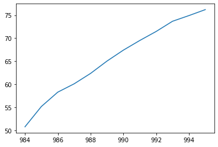

```python
MexicoDataSet['lifeExp'].plot()
```

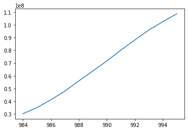

```python
MexicoDataSet['pop'].plot()
```

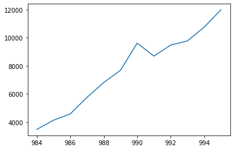

```python
MexicoDataSet['gdpPercap'].plot()
```

### Assignment 4.4. Is there any significant relationship between life expectancy and GDP in Mexico ?

### Tip: have a look at seaborn-based techniques to represent relationships between two variables.

### check the following link for alternatives: https://seaborn.pydata.org/tutorial.html

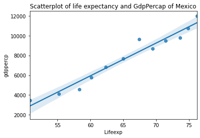

```python
ax = sns.regplot(x='lifeExp', y='gdpPercap', data=MexicoDataSet)
ax.set_title('Scatterplot of life expectancy and GdpPercap of Mexico');
ax.set_xlabel('Lifeexp');
ax.set_ylabel('gdppercp');
```

```python
#There is a linear relationship between life expectancy and GDP in Mexico
```

### Assignment 4.5. Is there any significant relationship between life expectancy and Population in Mexico ?

### Tip: have a look at seaborn-based techniques to represent relationships between two variables.

### check the following link for alternatives: https://seaborn.pydata.org/tutorial.html

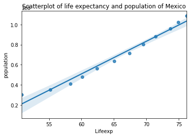

```python
ax = sns.regplot(x='lifeExp', y='pop', data=MexicoDataSet)
ax.set_title('Scatterplot of life expectancy and population of Mexico');
ax.set_xlabel('Lifeexp');
ax.set_ylabel('population');
```

```python
#There is a linear relationship between life expectancy and population in Mexico
```